# Erros Inatos do Metabolismo em Pernambuco

Recorte estadual (PE) · SIA · SIH · SIM · teste do pezinho e doença falciforme · 2010–2025 (SIM 2010–2024)

76.699

registros SIA core (EIM nomeados) — PE

26.187

AIH com EIM principal (SIH) — PE

241

óbitos por EIM (causa básica, SIM) — PE

36

óbitos infantis por EIM (<1 ano) — PE

Esta página recorta **Pernambuco (PE)** nas três bases do DATASUS — ambulatorial (SIA-PA, `uf_pcn`), internação (SIH-RD, `uf_res`) e mortalidade (SIM-DO, `uf_res`, 2010–2024) — e acrescenta um bloco do **teste do pezinho** com destaque para a **doença falciforme (D57)**, condição de altíssima carga no Nordeste. Todas as contagens seguem a **regra de supressão N<5** (LGPD; doença rara por município é especialmente sensível).

**Detecção/uso e mortalidade registrada — não prevalência.** Cada registro SIA é uma linha de produção ambulatorial (não uma pessoa); cada AIH é um evento de internação (a terapia de reposição enzimática — TRE — gera múltiplas AIH por paciente/ano); a mortalidade é a **registrada** na Declaração de Óbito. As três bases **não se somam**. A variação intraestadual reflege sobretudo **acesso a centros de referência** e qualidade de codificação — não incidência.

## Distribuição municipal dos EIM em Pernambuco

O mapa junta o código IBGE de município do geobr (7 dígitos) ao código do DATASUS (6 dígitos) por `substr(code_muni, 1, 6)`. Sem denominador populacional municipal confiável para doença rara, mostramos **contagem bruta** de registros/AIH por município de residência — a leitura correta é de **onde o SUS registra atendimento**, dominada pela **Região Metropolitana do Recife** (sede dos serviços especializados), não de onde os casos “existem”.

**Fernando de Noronha (código IBGE 260545) não é exibido no mapa.** O arquipélago fica isolado e distante do continente, o que obriga o mapa a “abrir espaço” e distorce o enquadramento da parte continental — foi **removido do polígono e do dado** para o mapa focar em PE continental. Os valores do arquipélago (não perdidos, apenas reportados à parte) estão logo abaixo de cada mapa.

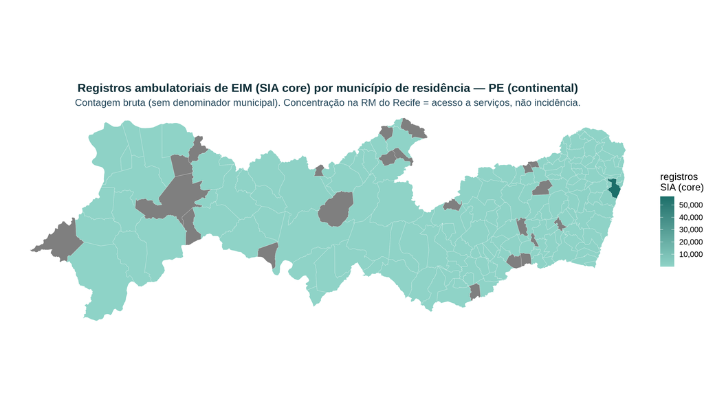

Fernando de Noronha (não exibido no mapa): **6 registros SIA** de EIM (supressão N<5 aplicada; “0” pode indicar ausência de registro ou valor suprimido).

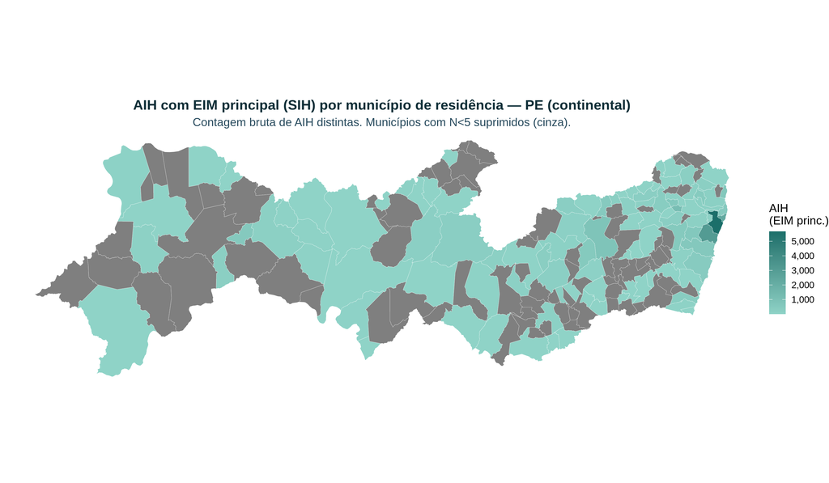

Fernando de Noronha (não exibido no mapa): **0 AIH** com EIM principal (supressão N<5 aplicada; “0” pode indicar ausência de registro ou valor suprimido).

**Municípios em cinza = supressão N<5 ou sem registro.** A concentração no Recife e entorno é o padrão esperado de uma rede de referência centralizada; municípios do interior “aparecem pouco” sobretudo por **encaminharem** seus pacientes aos centros da capital — o município de residência registrado pode inclusive já ser o da RM.

## Onde moram as pessoas com EIM: municípios e regiões de saúde

Os mapas acima mostram **onde o SUS registra atendimento**. Para planejar uma **rota itinerante de coleta de amostras**, a pergunta é outra: **onde moram as pessoas** com EIM em seguimento. Esta seção conta **pessoas distintas** (CNS criptografado) com EIM da camada core no BPA individualizado (consulta ou acompanhamento; quem só fez exame fica de fora) ou em APAC, pelo **município de residência** do atendimento mais recente no BPA-I. O município das APAC de medicamento do CEAF não é usado, porque em PE sai quase sempre Recife. A região é a **região de saúde** (Gerência Regional de Saúde, GERES) a que o município pertence.

2.651

pessoas com EIM (CNS) residentes em PE, 2010–2025

64,0%

atendidas em 2023–2025 (em seguimento)

48,4%

moram fora da I GERES (Recife e RM)

352

sem município confiável (só APAC do CEAF)

| # | Município | GERES | Pessoas (2010–2025) | Atendidas em 2023–2025 | Por 100 mil hab. | 5 doenças com mais pessoas (nº de pessoas) |
| --- | --- | --- | --- | --- | --- | --- |
| 1 | Recife | I · Recife | 534 | 312 | 35,9 | Fibrose cística (262) · Hipotireoidismo congênito (153) · Fenilcetonúria (PKU) (48) · Mucopolissacaridoses (MPS) (19) · Esfingolipidoses (Gaucher/Fabry/NP-C) (17) |
| 2 | Jaboatão dos Guararapes | I · Recife | 160 | 95 | 24,8 | Fibrose cística (85) · Hipotireoidismo congênito (31) · Mucopolissacaridoses (MPS) (16) · Fenilcetonúria (PKU) (13) · Glicoproteinoses (5) |
| 3 | Olinda | I · Recife | 124 | 78 | 35,4 | Fibrose cística (76) · Hipotireoidismo congênito (27) · Mucopolissacaridoses (MPS) (7) · Fenilcetonúria (PKU) (6) · Acidúrias orgânicas (N<5) |
| 4 | Caruaru | IV · Caruaru | 82 | 53 | 21,7 | Fibrose cística (41) · Hipotireoidismo congênito (24) · Fenilcetonúria (PKU) (7) · Mucopolissacaridoses (MPS) (6) · Amiloidose familiar (PAF-TTR) (N<5) |
| 5 | Paulista | I · Recife | 74 | 47 | 21,6 | Fibrose cística (39) · Hipotireoidismo congênito (26) · Fenilcetonúria (PKU) (N<5) · Defeitos da catalase e peroxidase (N<5) · Esfingolipidoses (Gaucher/Fabry/NP-C) (N<5) |
| 6 | Camaragibe | I · Recife | 45 | 30 | 30,5 | Fibrose cística (24) · Hipotireoidismo congênito (12) · Fenilcetonúria (PKU) (6) · Tirosinemia (N<5) · Defeitos da β-oxidação (FAOD) (N<5) |
| 7 | São Lourenço da Mata | I · Recife | 45 | 32 | 40,4 | Fibrose cística (20) · Hipotireoidismo congênito (15) · Amiloidose familiar (PAF-TTR) (N<5) · Fenilcetonúria (PKU) (N<5) · Tirosinemia (N<5) |
| 8 | Petrolina | VIII · Petrolina | 44 | 33 | 11,4 | Fibrose cística (25) · Hipotireoidismo congênito (13) · Fenilcetonúria (PKU) (N<5) · Esfingolipidoses (Gaucher/Fabry/NP-C) (N<5) · Glicogenoses (inclui Pompe) (N<5) |
| 9 | Cabo de Santo Agostinho | I · Recife | 40 | 16 | 19,7 | Fibrose cística (21) · Hipotireoidismo congênito (7) · Doença do xarope de bordo (MSUD) (N<5) · Fenilcetonúria (PKU) (N<5) · Esfingolipidoses (Gaucher/Fabry/NP-C) (N<5) |
| 10 | Vitória de Santo Antão | I · Recife | 37 | 22 | 27,6 | Fibrose cística (18) · Hipotireoidismo congênito (6) · Acidúrias orgânicas (N<5) · Amiloidose familiar (PAF-TTR) (N<5) · Fenilcetonúria (PKU) (N<5) |

Pessoa = CNS criptografado distinto com EIM (camada core) no BPA-I, fora do grupo SIGTAP 02 (exame), ou em APAC, 2010–2025; conta uma vez em cada doença que tem e uma vez no total. Município = residência no atendimento mais recente do BPA-I (ou no PA fora do CEAF, para quem não tem BPA-I). Atendidas em 2023–2025 = com algum registro nesses anos (em seguimento). Por 100 mil hab. = pessoas acumuladas no período ÷ população do Censo 2022: razão de uso do serviço, não prevalência. Supressão N<5.

A I GERES (Recife e região metropolitana) domina a lista acima por tamanho de população e porque fica perto dos centros de referência; quem mora ali já chega à capital. Para uma rota itinerante, a tabela abaixo deixa a I GERES de fora:

| # | Município | GERES | Pessoas (2010–2025) | Atendidas em 2023–2025 | Por 100 mil hab. | 5 doenças com mais pessoas (nº de pessoas) |
| --- | --- | --- | --- | --- | --- | --- |
| 1 | Caruaru | IV · Caruaru | 82 | 53 | 21,7 | Fibrose cística (41) · Hipotireoidismo congênito (24) · Fenilcetonúria (PKU) (7) · Mucopolissacaridoses (MPS) (6) · Amiloidose familiar (PAF-TTR) (N<5) |
| 2 | Petrolina | VIII · Petrolina | 44 | 33 | 11,4 | Fibrose cística (25) · Hipotireoidismo congênito (13) · Fenilcetonúria (PKU) (N<5) · Esfingolipidoses (Gaucher/Fabry/NP-C) (N<5) · Glicogenoses (inclui Pompe) (N<5) |
| 3 | Surubim | II · Limoeiro | 30 | 19 | 46,8 | Fibrose cística (17) · Hipotireoidismo congênito (8) · Fenilcetonúria (PKU) (N<5) · Galactosemia (N<5) · Síndrome de Lesch-Nyhan (N<5) |
| 4 | Serra Talhada | XI · Serra Talhada | 26 | 18 | 28,2 | Fibrose cística (21) · Tirosinemia (N<5) · Hipotireoidismo congênito (N<5) |
| 5 | Arcoverde | VI · Arcoverde | 24 | 18 | 30,9 | Fibrose cística (13) · Fenilcetonúria (PKU) (N<5) · Outros distúrbios de depósito de lipídios (N<5) · Defeitos da β-oxidação (FAOD) (N<5) · Glicogenoses (inclui Pompe) (N<5) |
| 6 | Araripina | IX · Ouricuri | 23 | 17 | 27,0 | Fibrose cística (9) · Hipotireoidismo congênito (6) · Doença do xarope de bordo (MSUD) (N<5) · Fenilcetonúria (PKU) (N<5) · Tirosinemia (N<5) |
| 7 | Gravatá | IV · Caruaru | 23 | 13 | 26,6 | Hipotireoidismo congênito (10) · Fenilcetonúria (PKU) (7) · Fibrose cística (5) · Hiperplasia adrenal congênita (HAC) (N<5) · Homocistinúria (N<5) |
| 8 | Garanhuns | V · Garanhuns | 21 | 16 | 14,7 | Hipotireoidismo congênito (9) · Fibrose cística (6) · Fenilcetonúria (PKU) (5) · Acidúrias orgânicas (N<5) · Mucopolissacaridoses (MPS) (N<5) |
| 9 | Salgueiro | VII · Salgueiro | 21 | 15 | 33,7 | Hipotireoidismo congênito (10) · Fibrose cística (5) · Fenilcetonúria (PKU) (N<5) · Distúrbios do metabolismo da frutose (N<5) · Mucopolissacaridoses (MPS) (N<5) |
| 10 | Santa Cruz do Capibaribe | IV · Caruaru | 21 | 15 | 21,4 | Fibrose cística (13) · Tirosinemia (N<5) · Outros distúrbios de depósito de lipídios (N<5) · Hiperplasia adrenal congênita (HAC) (N<5) · Hipotireoidismo congênito (N<5) |

Pessoa = CNS criptografado distinto com EIM (camada core) no BPA-I, fora do grupo SIGTAP 02 (exame), ou em APAC, 2010–2025; conta uma vez em cada doença que tem e uma vez no total. Município = residência no atendimento mais recente do BPA-I (ou no PA fora do CEAF, para quem não tem BPA-I). Atendidas em 2023–2025 = com algum registro nesses anos (em seguimento). Por 100 mil hab. = pessoas acumuladas no período ÷ população do Censo 2022: razão de uso do serviço, não prevalência. Supressão N<5.

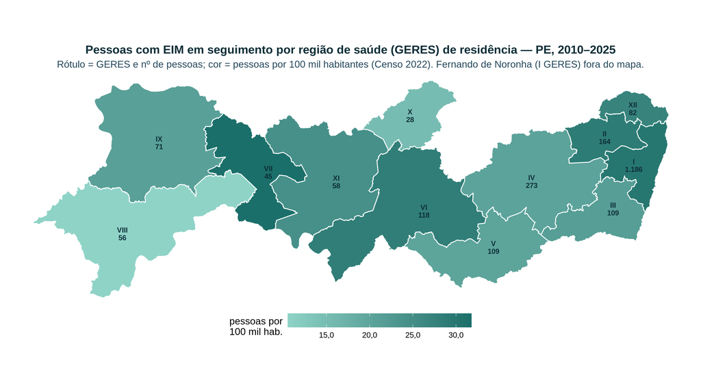

| # | GERES | Região de saúde (sede) | Pessoas (2010–2025) | Atendidas em 2023–2025 | Por 100 mil hab. | 5 doenças com mais pessoas (nº de pessoas) |
| --- | --- | --- | --- | --- | --- | --- |
| 1 | I | Recife | 1.186 | 723 | 30,0 | Fibrose cística (597) · Hipotireoidismo congênito (311) · Fenilcetonúria (PKU) (96) · Mucopolissacaridoses (MPS) (63) · Esfingolipidoses (Gaucher/Fabry/NP-C) (30) |
| 2 | IV | Caruaru | 273 | 185 | 20,4 | Fibrose cística (122) · Hipotireoidismo congênito (83) · Fenilcetonúria (PKU) (32) · Mucopolissacaridoses (MPS) (16) · Esfingolipidoses (Gaucher/Fabry/NP-C) (6) |
| 3 | II | Limoeiro | 164 | 101 | 28,9 | Fibrose cística (89) · Hipotireoidismo congênito (41) · Mucopolissacaridoses (MPS) (15) · Fenilcetonúria (PKU) (12) · Acidúrias orgânicas (N<5) |
| 4 | VI | Arcoverde | 118 | 85 | 28,4 | Fibrose cística (52) · Hipotireoidismo congênito (28) · Mucopolissacaridoses (MPS) (11) · Fenilcetonúria (PKU) (7) · Tirosinemia (N<5) |
| 5 | III | Palmares | 109 | 65 | 21,5 | Fibrose cística (55) · Hipotireoidismo congênito (29) · Fenilcetonúria (PKU) (9) · Esfingolipidoses (Gaucher/Fabry/NP-C) (8) · Glicoproteinoses (5) |
| 6 | V | Garanhuns | 109 | 72 | 20,2 | Hipotireoidismo congênito (41) · Fibrose cística (33) · Fenilcetonúria (PKU) (18) · Mucopolissacaridoses (MPS) (6) · Acidúrias orgânicas (N<5) |
| 7 | XII | Goiana | 82 | 51 | 27,1 | Fibrose cística (38) · Hipotireoidismo congênito (30) · Esfingolipidoses (Gaucher/Fabry/NP-C) (5) · Fenilcetonúria (PKU) (N<5) · Distúrbios do ciclo da ureia (N<5) |
| 8 | IX | Ouricuri | 71 | 45 | 21,0 | Fibrose cística (30) · Hipotireoidismo congênito (21) · Fenilcetonúria (PKU) (9) · Mucopolissacaridoses (MPS) (6) · Doença do xarope de bordo (MSUD) (N<5) |
| 9 | XI | Serra Talhada | 58 | 44 | 24,5 | Fibrose cística (31) · Hipotireoidismo congênito (12) · Acidúrias orgânicas (N<5) · Doença do xarope de bordo (MSUD) (N<5) · Fenilcetonúria (PKU) (N<5) |
| 10 | VIII | Petrolina | 56 | 41 | 10,5 | Fibrose cística (29) · Hipotireoidismo congênito (18) · Fenilcetonúria (PKU) (6) · Esfingolipidoses (Gaucher/Fabry/NP-C) (N<5) · Galactosemia (N<5) |
| 11 | VII | Salgueiro | 45 | 32 | 31,8 | Hipotireoidismo congênito (19) · Fibrose cística (15) · Fenilcetonúria (PKU) (5) · Doença do xarope de bordo (MSUD) (N<5) · Esfingolipidoses (Gaucher/Fabry/NP-C) (N<5) |
| 12 | X | Afogados da Ingazeira | 28 | 20 | 15,1 | Fibrose cística (12) · Hipotireoidismo congênito (11) · Amiloidose familiar (PAF-TTR) (N<5) · Fenilcetonúria (PKU) (N<5) · Glicogenoses (inclui Pompe) (N<5) |

Pessoa = CNS criptografado distinto com EIM (camada core) no BPA-I, fora do grupo SIGTAP 02 (exame), ou em APAC, 2010–2025; conta uma vez em cada doença que tem e uma vez no total. Município = residência no atendimento mais recente do BPA-I (ou no PA fora do CEAF, para quem não tem BPA-I). Atendidas em 2023–2025 = com algum registro nesses anos (em seguimento). Por 100 mil hab. = pessoas acumuladas no período ÷ população do Censo 2022: razão de uso do serviço, não prevalência. Supressão N<5.

**Leitura para a rota de coleta.**

- **Fora da I GERES**, as regiões com mais pessoas são IV (Caruaru, 273), II (Limoeiro, 164) e VI (Arcoverde, 118); a maior razão por habitante é a da VII GERES (Salgueiro, 31,8 por 100 mil, contra 25,4 no estado). Uma razão alta pode indicar aglomerado de casos (efeito fundador, consanguinidade) ou só um serviço local que acompanha bem; a coleta ajuda a separar uma coisa da outra.
- **Pessoas em seguimento, não registros nem internações.** O SIH ficou fora da contagem: sem CNS, a pessoa seria a chave nascimento × sexo × município, que em PE infla com erro de codificação de hospital local. Em Limoeiro, por exemplo, há 183 chaves do SIH com fenilcetonúria sem nenhum CNS correspondente no BPA-I, contra N<5 pessoas com PKU em seguimento ambulatorial.
- **Sem município confiável:** 352 pessoas só aparecem em APAC do CEAF (sobretudo fibrose cística e hiperplasia adrenal congênita (HAC)), cujo município em PE sai quase sempre Recife. Elas existem, mas não entram em nenhum município nem região; a rede de dispensação do CEAF é o caminho para alcançá-las.
- **Residência registrada.** O município é o do atendimento mais recente; mudança de endereço, endereço de parente na capital para facilitar o tratamento e erro de digitação deslocam pessoas. A camada core inclui condições da triagem neonatal (hipotireoidismo congênito, HAC), que pesam na lista de doenças.

## Estrutura etária × sexo em Pernambuco

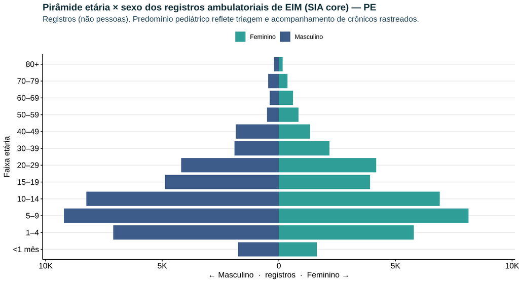

**Registros, não pessoas.** A idade no SIA vem em anos inteiros e é mal preenchida — a barra `<1 mês` × `1–11 m` é frágil. A pirâmide indica **estrutura de uso do serviço**, não a distribuição etária dos casos de EIM na população pernambucana.

## Procedimentos SIGTAP mais frequentes em PE

Cada registro SIA carrega um procedimento **SIGTAP** (`pa_proc_id`). Os mais frequentes em PE revelam o que o SUS de fato executa: **medicamentos de alto custo** (alfadornase e pancreatina na fibrose cística; fórmulas metabólicas na PKU), **consultas especializadas** e **exames diagnósticos**. Os nomes vêm da tabela SIGTAP (`microdatasus::sigtab`); códigos sem correspondência saem marcados `[VERIFICAR nome SIGTAP]`.

| Cód. SIGTAP | Procedimento | Registros | Valor aprovado (R$) |
| --- | --- | --- | --- |
| 0604580010 | Pancreatina 10.000 ui (por capsula) | 12.035 | R$ 2.469.516 |
| 0604440014 | Alfadornase 2,5 mg (por ampola) | 11.473 | R$ 8.182.421 |
| 0604580029 | Pancreatina 25000 ui (por capsula) | 11.018 | R$ 3.089.832 |
| 0604060025 | Complemento alimentar p/ paciente fenilcetonurico maior de 1 ano - formula de aminoacidos isenta de | 5.468 | R$ 0 |
| 0302040021 | Atendimento fisioterapeutico em paciente com transtorno respiratorio sem complicacoes sistemicas | 5.074 | R$ 38.994 |
| 0301120048 | Acompanhamento de paciente com hipotireoidismo congenito | 4.191 | R$ 115.252 |
| 0604240031 | Imiglucerase 400 u injetavel (por frasco-ampola) | 3.830 | R$ 0 |
| 0604810016 | Tobramicina 300mg/5 ml solucao inalatoria (por ampola) | 2.713 | R$ 0 |
| 0604240082 | Galsulfase 1 mg/ml solucao injetavel (por frasco ampola de 5 ml) | 2.074 | R$ 0 |
| 0301010196 | Avaliacao clinica para diagnostico de doencas raras - eixo i: 1-anomalias congenitas ou de mani | 1.919 | R$ 526.400 |
| 0604420013 | Fludrocortisona 0,1 mg (por comprimido) | 1.803 | R$ 0 |
| 0301010218 | Avaliacao clinica de diagnostico de doencas raras eixo i: 3 - erros inatos de metabolismo | 1.485 | R$ 329.400 |

Nomes via microdatasus::sigtab. Supressão N<5. Detecção/uso, não prevalência.

## Quantos pacientes há por trás dos registros?

O SIA-PA não traz identificador do paciente, mas as **APAC de medicamentos e de laudos diversos** trazem o Cartão Nacional de Saúde **criptografado**, estável entre meses e anos. Ligando cada APAC do PA a elas pelo número da autorização, contamos **pacientes distintos** de EIM em Pernambuco, sem estimativa. Quem só aparece em consulta ou exame (BPA, sem APAC) fica fora desta contagem.

1.465

pacientes com APAC de EIM em PE (2010–2025)

675

pacientes com APAC em 2024

42,8

registros de APAC por paciente

| Subgrupo | Pacientes (2010–2025) | Pacientes em 2024 | Registros de APAC | Registros por paciente |
| --- | --- | --- | --- | --- |
| fibrose cistica | 772 | 355 | 41.065 | 53,2 |
| mucopolissacaridose | 124 | 79 | 4.644 | 37,5 |
| aminoacidopatia PKU | 98 | 49 | 6.276 | 64,0 |
| hiperplasia adrenal cong | 92 | 31 | 2.096 | 22,8 |
| esfingolipidose outras | 82 | 45 | 4.440 | 54,1 |
| amiloidose familiar | 75 | 36 | 1.362 | 18,2 |
| metab cobre | 47 | 19 | 1.705 | 36,3 |
| glicogenose | 32 | 10 | 269 | 8,4 |
| glicoproteinose | 29 | N<5 | 62 | 2,1 |
| galactosemia | 20 | 9 | 110 | 5,5 |
| aminoacidopatia tirosina | 18 | N<5 | 53 | 2,9 |
| deposito lipidios | 14 | 8 | 92 | 6,6 |
| faod | 13 | 6 | 88 | 6,8 |
| transporte aminoacidos | 12 | N<5 | 41 | 3,4 |
| acuduria organica | 10 | N<5 | 39 | 3,9 |
| ciclo ureia | 9 | N<5 | 43 | 4,8 |
| aminoacidopatia MSUD | 9 | N<5 | 52 | 5,8 |
| hipotireoidismo congenito | 8 | 0 | 25 | 3,1 |
| lipofuscinose NCL | 6 | N<5 | 58 | 9,7 |
| defeito catalase | 5 | N<5 | 30 | 6,0 |

Paciente = CNS criptografado distinto nas APAC de medicamentos e de laudos diversos, ligado ao PA pelo número da APAC (residência do paciente em PE). O CNS é usado só para contar (LGPD). Não inclui quem só tem consulta ou exame. Supressão N<5.

**Por que a contagem mudou em relação ao pseudo-ID.** Em Pernambuco, o pseudo-ID errava nos dois sentidos e, na fibrose cística, **subestimava**: 772 pacientes verdadeiros contra um intervalo de 439–681 estimado sobre os mesmos registros. A causa é o município do paciente nas APAC do Componente Especializado de PE, que sai quase sempre como Recife: pacientes diferentes com o mesmo sexo e o mesmo ano de nascimento colapsavam num só. O CNS não depende do município.

## Internações (SIH) em Pernambuco

26.187

AIH com EIM principal

42.216

AIH com EIM em qualquer campo

0,0 dias

permanência mediana (principal)

0,3%

das AIH-EIM (principal) usaram UTI

O SIH tem **dois sabores não somáveis**: *diagnóstico principal* (a EIM foi o motivo da internação) e *qualquer campo* (principal + secundários). Em PE, como no país, as **mucopolissacaridoses (MPS)** dominam o volume hospitalar — cada paciente gera múltiplas AIH de infusão de **TRE** (terapia de reposição enzimática).

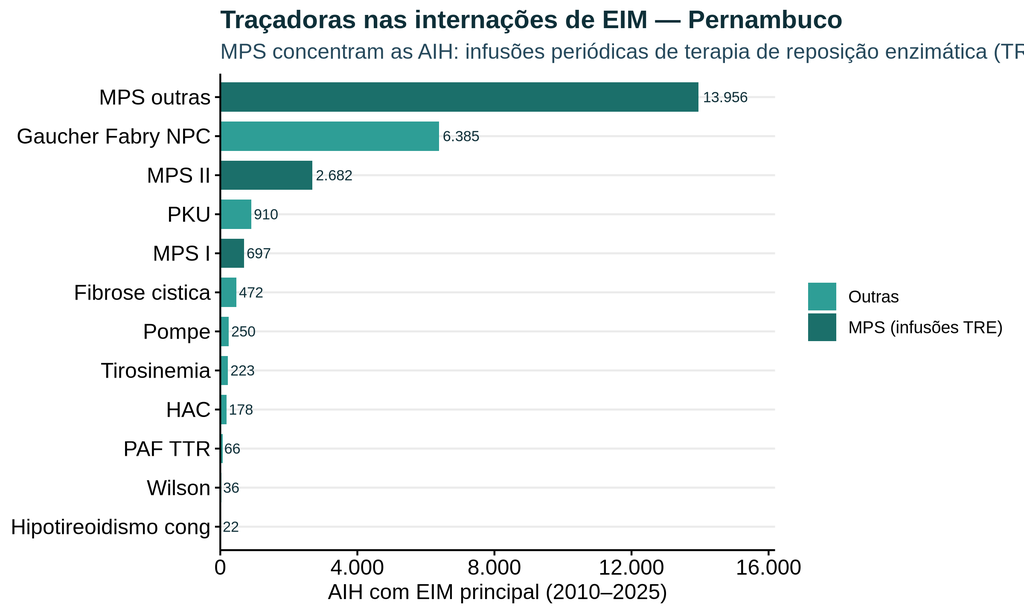

### Principais doenças que motivam a internação (diagnóstico principal)

A tabela abaixo tabula `diag_princ` — o **diagnóstico principal** da AIH, ou seja, o **motivo** da internação — por `subgrupo` clínico (rótulo amigável do CID), não pela traçadora individual. Reforça a leitura do gráfico anterior sob outro agrupamento e evidencia a **ressalva de intensidade**: MPS e demais doenças de depósito internam repetidamente para infusão de TRE, então o nº de AIH mede uso do serviço, não nº de pacientes.

| Doença | AIH (diag. principal) | % do total (principal) | Perm. mediana (dias) |
| --- | --- | --- | --- |
| Mucopolissacaridoses (MPS) | 17.335 | 66,2 | 0,0 |
| Esfingolipidoses (Gaucher/Fabry/NP-C) | 6.385 | 24,4 | 0,0 |
| Fenilcetonúria (PKU) | 866 | 3,3 | 2,0 |
| Fibrose cística | 472 | 1,8 | 13,5 |
| Glicogenoses (inclui Pompe) | 250 | 1,0 | 0,0 |
| Tirosinemia | 223 | 0,9 | 2,0 |
| Hiperplasia adrenal congênita (HAC) | 178 | 0,7 | 9,0 |
| Amiloidose familiar (PAF-TTR) | 130 | 0,5 | 2,0 |
| Outras hiperfenilalaninemias | 44 | 0,2 | 2,0 |
| Porfirias agudas | 44 | 0,2 | 0,0 |

diag_princ = motivo da internação (não somar com 'qualquer campo'). Nº de AIH mede intensidade de tratamento (infusões TRE em MPS/esfingolipidoses), não nº de pacientes. Supressão N<5.

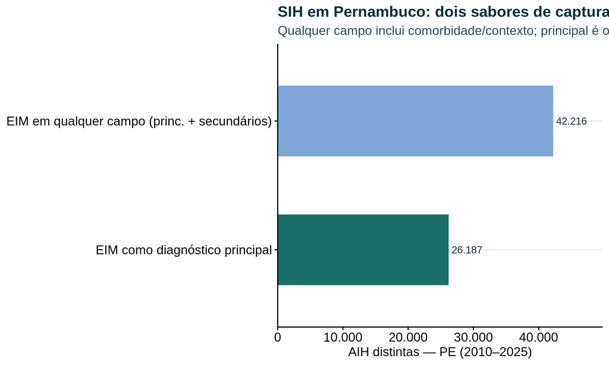

**A permanência mediana ~0 dia** reflete o **hospital-dia de infusão** (MPS/Gaucher/Fabry): a maioria das AIH de EIM em PE é de terapia crônica de curta duração, não de descompensação grave. A gravidade aguda está na cauda longa e no uso de UTI, concentrado nos EIM letais precoces (ciclo da ureia, tirosinemia).

## Doenças separadas pelo medicamento dispensado (APAC)

Vários códigos CID-10 agregam doenças distintas — **E76.2** (“outras MPS” = MPS III, IVA, VI e VII), **E74.0** (todas as glicogenoses, inclusive **Pompe**), **E75.2** (Gaucher, Fabry, Niemann-Pick, Krabbe, LDM…) e **E83.0** (Wilson, Menkes e outros). Como cada medicamento do CEAF tem procedimento SIGTAP próprio na APAC, o **medicamento dispensado identifica o tipo** (eixo A, *desambiguação*). Em CIDs já específicos, o medicamento ainda revela **fenótipo ou genótipo** — modulador de CFTR, sapropterina, fludrocortisona, tafamidis (eixo B, *estratificação*). As AIH, que não registram medicamento, são vinculadas às APAC pela chave sexo × ano de nascimento × município (ou, na falta, UF) — método e limites em `scripts/separacao_medicamento_apac.R`.

37

pacientes com MPS VI em TRE/mês em PE (2024) — 4,3× a taxa nacional

19,1%

dos pacientes em galsulfase do país estão em PE

26

pacientes com Gaucher em TRE/mês em PE

23,9%

dos pacientes em ivacaftor isolado do país estão em PE

### A. Desambiguação — pacientes em tratamento, Pernambuco vs. Brasil

| Grupo | Tipo (pelo medicamento) | PE · pacientes/mês | PE · por milhão | Brasil · pacientes/mês | Brasil · por milhão | Razão PE/Brasil | % do Brasil em PE |
| --- | --- | --- | --- | --- | --- | --- | --- |
| MPS | MPS I | N<5 | — | 90 | 0,4 | — | — |
| MPS | MPS II | 11 | 1,2 | 148 | 0,7 | 1,7 | 7,4 |
| MPS | MPS IVA | 19 | 2,0 | 120 | 0,6 | 3,5 | 15,8 |
| MPS | MPS VI | 37 | 3,9 | 194 | 0,9 | 4,3 | 19,1 |
| MPS | MPS VII | 0 | 0 | 12 | 0,1 | — | — |
| Glicogenoses | Pompe (GSD II) | N<5 | — | 53 | 0,2 | — | — |
| Esfingolipidoses (E75.2) | Gaucher | 26 | 2,8 | 688 | 3,2 | 0,9 | 3,9 |
| Esfingolipidoses (E75.2) | Fabry | N<5 | — | N<5 | — | — | — |
| Esfingolipidoses (E75.2) | Gaucher tipo 1 ou NP-C | N<5 | — | 20 | 0,1 | — | — |
| Metabolismo do cobre (E83.0) | Wilson | 15 | 1,6 | 448 | 2,1 | 0,7 | 3,3 |

Uma APAC do CEAF agrupa os medicamentos do paciente e fica ativa por mês; a mediana mensal de APAC distintas estima os pacientes EM TRATAMENTO no ano (não os diagnosticados). Miglustate = Gaucher tipo 1 ou NP-C (não separáveis, salvo quando a mesma APAC tem TRE de Gaucher). Fabry: TRE no CEAF só a partir de 2025-03 (código 06.04.24.012-0, provável alfagalsidase — nome a verificar no SIGTAP), daí 0 no ano de referência. População: Censo 2022 (base constante). Supressão N<5. Tratamento por via judicial fora do CEAF não aparece.

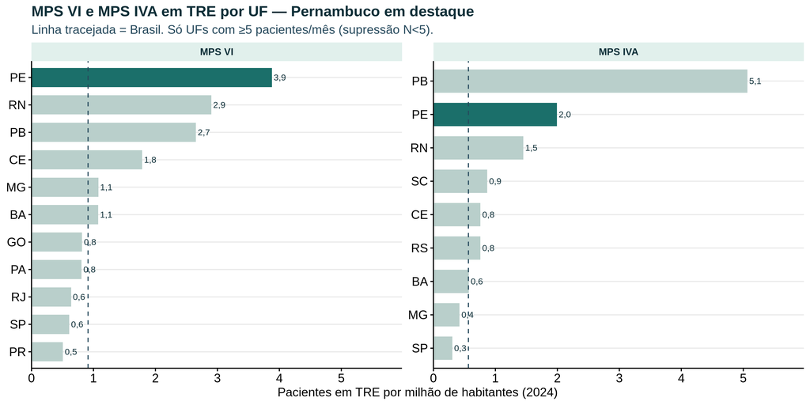

### Internações (SIH) de PE atribuídas por tipo

| Grupo | Tipo | Como foi atribuído | AIH | % das AIH do grupo | Pacientes (SIH) | Perm. mediana (dias) |
| --- | --- | --- | --- | --- | --- | --- |
| MPS | MPS I | CID específico | 149 | 0,9 | 25 | 0,0 |
| MPS | MPS I | vínculo à APAC (UF) | 146 | 0,8 | 7 | 0,0 |
| MPS | MPS I | vínculo à APAC (município) | 402 | 2,3 | 5 | 0,0 |
| MPS | MPS II | CID específico | 175 | 1,0 | 37 | 0,0 |
| MPS | MPS II | vínculo à APAC (UF) | 441 | 2,5 | 22 | 0,0 |
| MPS | MPS II | vínculo à APAC (município) | 2.066 | 11,9 | 15 | 0,0 |
| MPS | MPS IVA | vínculo à APAC (UF) | 200 | 1,2 | 23 | 0,0 |
| MPS | MPS IVA | vínculo à APAC (município) | 165 | 1,0 | 10 | 0,0 |
| MPS | MPS VI | vínculo à APAC (UF) | 1.959 | 11,3 | 28 | 0,0 |
| MPS | MPS VI | vínculo à APAC (município) | 7.243 | 41,8 | 38 | 0,0 |
| MPS | MPS III/IV/VI/VII — sem medicamento vinculado | sem medicamento | 267 | 1,5 | 39 | 0,0 |
| MPS | Não separável (vínculo ambíguo) | vínculo à APAC (UF) | 1.951 | 11,3 | 58 | 0,0 |
| MPS | Não separável (vínculo ambíguo) | vínculo à APAC (município) | 2.171 | 12,5 | 17 | 0,0 |
| Glicogenoses | Pompe (GSD II) | vínculo à APAC (UF) | 60 | 24,0 | 7 | 0,0 |
| Glicogenoses | Pompe (GSD II) | vínculo à APAC (município) | 85 | 34,0 | N<5 | 0,0 |
| Glicogenoses | Glicogenose sem TRE (não-Pompe ou Pompe sem TRE) | sem medicamento | 105 | 42,0 | 31 | 0,0 |
| Esfingolipidoses (E75.2) | Gaucher | vínculo à APAC (UF) | 959 | 15,0 | 49 | 0,0 |
| Esfingolipidoses (E75.2) | Gaucher | vínculo à APAC (município) | 4.249 | 66,5 | 41 | 0,0 |
| Esfingolipidoses (E75.2) | Gaucher tipo 1 ou NP-C | vínculo à APAC (município) | 12 | 0,2 | N<5 | 0,0 |
| Esfingolipidoses (E75.2) | E75.2 sem medicamento (NP-A/B, Krabbe, LDM, Farber… ou sem tratamento) | sem medicamento | 1.156 | 18,1 | 61 | 0,0 |
| Esfingolipidoses (E75.2) | Não separável (vínculo ambíguo) | vínculo à APAC (UF) | 9 | 0,1 | N<5 | 0,0 |
| Metabolismo do cobre (E83.0) | Wilson | vínculo à APAC (UF) | 16 | 45,7 | 13 | 4,5 |
| Metabolismo do cobre (E83.0) | Wilson | vínculo à APAC (município) | N<5 | — | N<5 | 0,0 |
| Metabolismo do cobre (E83.0) | E83.0 sem quelante (Menkes, outros, ou Wilson em zinco) | sem medicamento | 19 | 54,3 | 19 | 3,0 |

Vínculo (município) = mesmo sexo, ano de nascimento e município de residência que uma APAC com medicamento; vínculo (UF) = idem na mesma UF, usado quando o município não casa. Só são aceitos tipos compatíveis com o CID da AIH; vários candidatos são resolvidos pela interseção das doenças (miglustate + TRE de Gaucher = Gaucher). Ambíguo = a chave casa com tipos incompatíveis entre si. 'Sem medicamento' = sem APAC correspondente (MPS III, glicogenoses hepáticas/musculares, NP-A/B, Krabbe, LDM, tratamento judicial ou falha de vínculo). % sobre as células não suprimidas. Paciente SIH = data de nascimento × sexo × município. Supressão N<5.

### B. Estratificação — o que o medicamento revela sobre genótipo e fenótipo

| Grupo | Medicamento → o que indica | PE · pacientes/mês | PE · % do grupo no CEAF | Brasil · pacientes/mês | Brasil · % do grupo no CEAF | Razão PE/Brasil (por milhão) | % do Brasil em PE |
| --- | --- | --- | --- | --- | --- | --- | --- |
| Fibrose cística | ETI — ≥1 F508del | 62 | 44,6 | 1.807 | 39,3 | 0,8 | 3,4 |
| Fibrose cística | Ivacaftor — variante de gating | 11 | 7,9 | 46 | 1,0 | 5,3 | 23,9 |
| PKU | Sapropterina — responsiva a BH4 | 9 | 22,5 | 75 | 5,1 | 2,7 | 12,0 |
| HAC | Fludrocortisona — perdedora de sal provável | 16 | — | 719 | — | 0,5 | 2,2 |
| ATTRv (PAF-TTR) | Tafamidis — ATTRv em tratamento | 32 | — | 772 | — | 0,9 | 4,1 |

4º trimestre para captar a rampa do ETI, ofertado a partir de 2024-04. ETI = elexacaftor/tezacaftor/ivacaftor, incorporado para ≥6 anos com ao menos uma F508del (Portaria SECTICS/MS 47/2023); ivacaftor isolado = variantes de gating (critério a confirmar no PCDT). % do grupo no CEAF: denominador = APAC com qualquer medicamento do grupo (FC: alfadornase, pancreatina, tobramicina, moduladores; PKU: fórmula metabólica, sapropterina) — só para FC e PKU. Fludrocortisona e tafamidis sem denominador comparável. Supressão N<5.

**Leitura.**

- **MPS VI é a MPS de Pernambuco.** Com 37 pacientes em galsulfase por mês, PE tem 3,9 pacientes por milhão — 4,3 vezes a taxa nacional — e reúne 19,1% dos pacientes em TRE para MPS VI do país, com apenas 4,5% da população. Outras UFs com taxa ≥1,5× a nacional (por milhão): RN (2,9), PB (2,7), CE (1,8).
- **MPS IVA também se concentra no Nordeste.** PE tem 19 pacientes em alfaelosulfase (3,5× a taxa nacional), e a maior taxa do país é de PB (5,1 por milhão). O agrupamento nordestino das duas MPS é compatível com efeito fundador e consanguinidade regional — **hipótese** a testar com dado genético (haplótipos das variantes *ARSB* e *GALNS*), não conclusão deste descritivo.
- **O volume do SIH de PE é de faturamento, não de morbidade.** PE responde por 81,6% das AIH de infusão de MPS com CID E76.2 do país (13.954 de 17.110, procedimento 03.03.03.004-6), com cerca de 17,8% dos pacientes em TRE para MPS IVA/VI: a infusão semanal é faturada como AIH de hospital-dia em PE muito mais do que nas outras UFs.
- **E75.2 em PE é sobretudo Gaucher.** 81,6% das AIH de E75.2 vinculam a TRE de Gaucher (26 pacientes/mês, 0,9× a taxa nacional). As AIH **sem medicamento** (18,1%) mostram dois perfis: por paciente, mediana de 19 anos — vários são pacientes de MPS com AIH codificada como E75.2; por AIH, 80,4% mulheres e mediana de 65 anos, com infusões regulares — padrão compatível com TRE de Fabry por via judicial antes da oferta no CEAF (2025-03), a confirmar.
- **Pompe concentra 58,0% das AIH de glicogenose de PE** (infusão quinzenal de alfa-alglicosidase), mas são menos de 5 pacientes em TRE por mês. As demais AIH de E74.0 seguem sem tipo: não há medicamento que identifique as glicogenoses hepáticas e musculares — separá-las exige teste genético.
- **Fibrose cística: o genótipo já está no dado.** 44,6% dos pacientes com FC no CEAF em PE usam ETI (≥1 F508del; Brasil 39,3%), e PE reúne 23,9% dos pacientes em **ivacaftor isolado** do país — 7,9% da FC estadual contra 1,0% no Brasil. Excesso de variantes de gating em PE é sinal genético a investigar.
- **PKU:** 22,5% dos pacientes com PKU no CEAF em PE usam sapropterina (Brasil 5,1%) — diferença que pode refletir genótipo *PAH* responsivo a BH4 ou prática de prescrição; o teste de resposta e o genótipo distinguem.
- **Limites do vínculo.** O município do paciente na APAC do CEAF não é confiável em PE (quase todas saem com Recife), daí o segundo nível por UF; 29,5% das AIH E76.2 de PE ficam **ambíguas** (a chave casa com MPS IVA e VI). A chave não é identificador (LGPD): o resultado é atribuição provável, não diagnóstico.

## Óbitos (SIM) em Pernambuco — 2010–2024

241

óbitos por EIM (causa básica)

4,2%

dos óbitos c/ EIM têm EIM como causa básica

18,0 anos

idade mediana ao óbito (causa básica)

36

óbitos infantis por EIM (<1 ano)

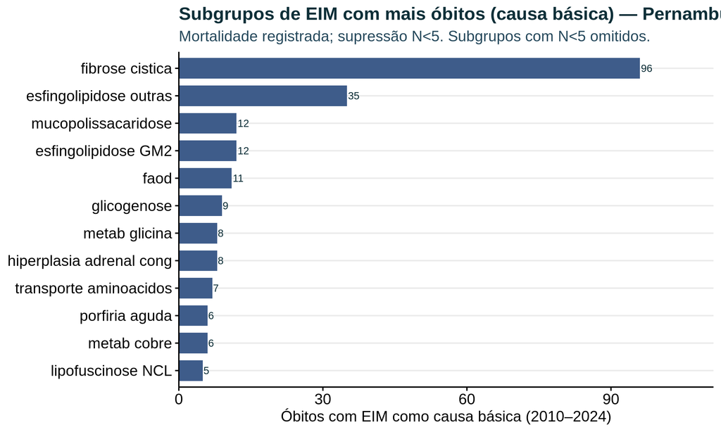

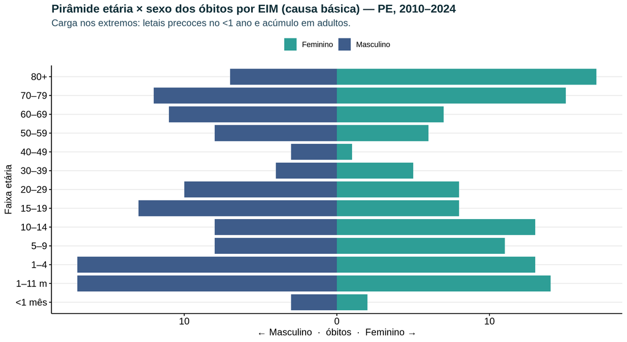

## Teste do pezinho em PE — destaque para a doença falciforme (D57)

Pernambuco é Nordeste: região de **alta prevalência de doença falciforme** e de maior consanguinidade — contexto relevante para os EIM e para as condições rastreadas pelo pezinho. O painel do pezinho é analisado em **escopo isolado** e **nunca somado** às taxas de EIM.

| Doença | SIA (registros) | SIH (AIH princ.) | SIM (causa básica) |
| --- | --- | --- | --- |
| Doença falciforme (D57) | 87.042 | 8.148 | 273 |
| Talassemias (D56) | 3.658 | 96 | 10 |
| IDP / SCID (D81) | 731 | 119 | 7 |
|  | 255 | N<5 | N<5 |
| Toxoplasmose congênita (P37.1) | 73 | 968 | 11 |
| metab_manifest_alhures | N<5 | N<5 | N<5 |

Escopo isolado (painel_pezinho); NUNCA somado às taxas de EIM. Supressão N<5. Detecção/uso, não prevalência.

87.042

registros SIA de doença falciforme (D57) — PE

8.148

AIH com falciforme (D57) — PE

273

óbitos por falciforme (causa básica) — PE

**Doença falciforme domina o painel do pezinho em PE.** Com 87.042 registros SIA, 8.148 AIH e 273 óbitos por causa básica, a D57 é de longe a maior carga da triagem no estado — coerente com a **alta prevalência do traço/doença falciforme no Nordeste**. É uma condição **não-EIM**, rastreada pelo mesmo teste, mantida em escopo isolado e **nunca somada** às taxas de EIM desta página.

## Recife — a capital

Recife (código IBGE 6 dígitos **261160**) é a capital e sede da rede de referência estadual em EIM. Esta seção recorta os dados de PE **apenas ao município de Recife** (SIA `pa_munpcn`, SIH `munic_res`, SIM `codmunres` iniciando em 261160) para quantificar a concentração.

56.867

registros SIA core (EIM) — Recife

5.673

AIH com EIM principal (SIH) — Recife

44

óbitos por EIM (causa básica, SIM) — Recife

74,1%

dos registros SIA de PE ocorrem em Recife

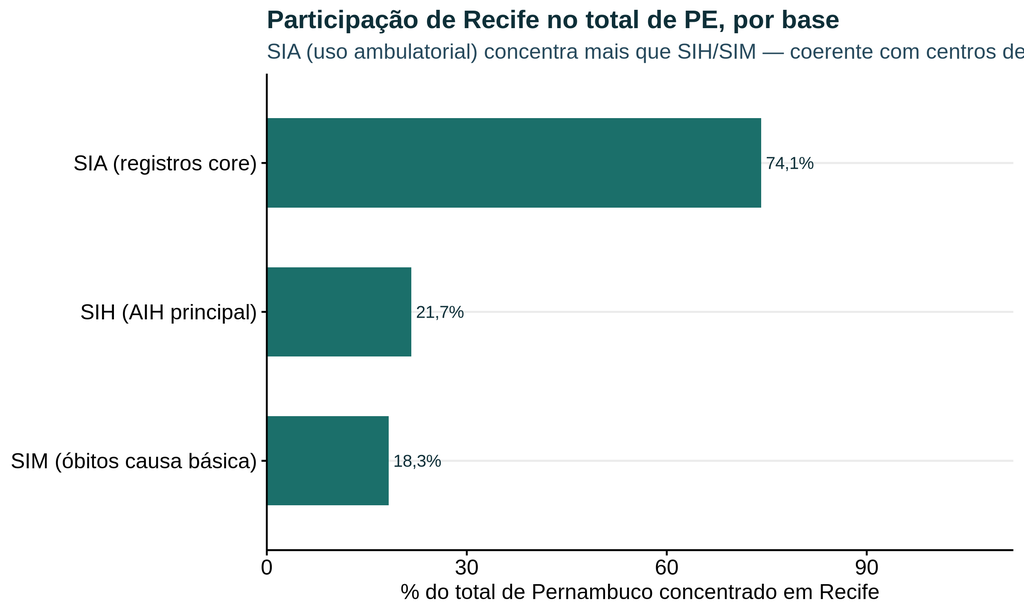

Recife concentra **74,1%** dos registros SIA, **21,7%** das AIH com EIM principal e **18,3%** dos óbitos por causa básica do estado — participação bem maior no ambulatorial (uso contínuo, concentrado no serviço de referência) do que na mortalidade (que ocorre onde a pessoa mora/morre, mais distribuída pelo interior).

### Quantos indivíduos em Recife? (pseudo-individualização)

56.867

registros SIA core (EIM) — Recife

663–983

indivíduos estimados em Recife (intervalo)

63,0

registros por indivíduo — Recife

25,8%

dos indivíduos estimados de PE são atendidos em Recife

**Concentra registros mais do que indivíduos.** Recife tem **74,1% dos registros** ambulatoriais de EIM de PE, mas apenas **~25,8% dos indivíduos estimados** — e a **intensidade de uso é maior na capital** (**~63,0 registros/indivíduo** em Recife vs **~21,9** no estado). É a assinatura da **rede de referência**: relativamente menos pacientes, cada um com muito mais atendimentos (infusões de TRE, seguimento crônico), inclusive pacientes **encaminhados do interior** via TFD que passam a ser atendidos — e por vezes registrados — na capital. Nas APAC do CEAF o efeito é extremo: o município do paciente sai quase sempre como Recife, qualquer que seja a residência (ver a seção de medicamentos acima), então os indivíduos “de Recife” incluem pacientes do interior em tratamento pelo CEAF. Reforça que o dado de Recife mede **acesso/oferta**, não onde os casos “existem”. Intervalo, não ponto; pseudo-ID é agrupador, não identificador (LGPD). Esta seção ainda usa o pseudo-ID, porque a residência registrada nas APAC de PE não permite separar Recife do interior; ele tende a juntar pacientes diferentes em PE (ver a contagem pelo CNS acima).

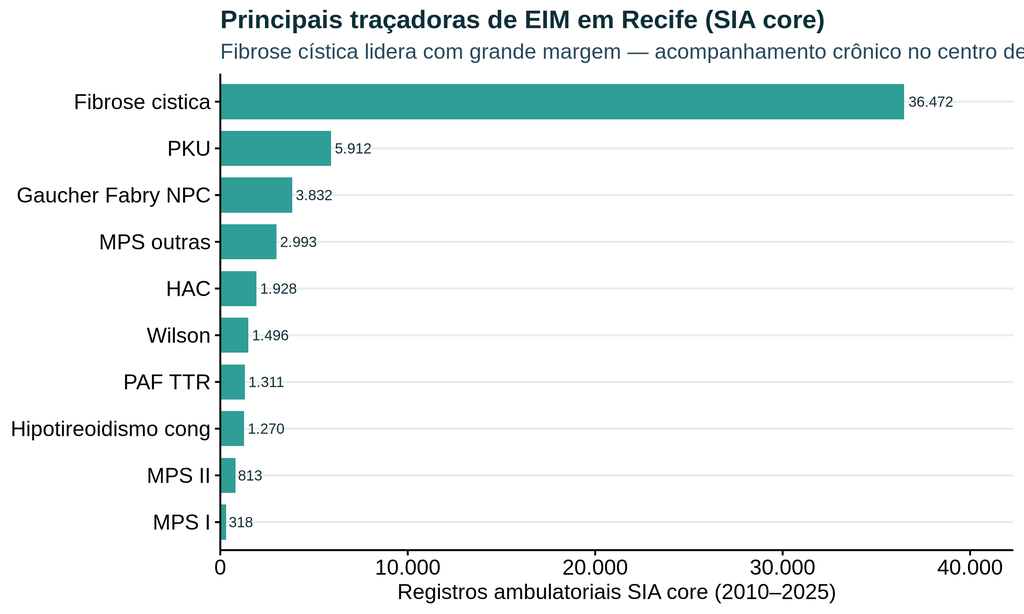

| Cód. SIGTAP | Procedimento | Registros | Valor aprovado (R$) |
| --- | --- | --- | --- |
| 0604580029 | Pancreatina 25000 ui (por capsula) | 10.475 | R$ 2.898.414 |
| 0604580010 | Pancreatina 10.000 ui (por capsula) | 10.268 | R$ 1.961.476 |
| 0604440014 | Alfadornase 2,5 mg (por ampola) | 9.692 | R$ 6.140.169 |
| 0604060025 | Complemento alimentar p/ paciente fenilcetonurico maior de 1 ano - formula de aminoacidos isenta de | 4.895 | R$ 0 |
| 0604240031 | Imiglucerase 400 u injetavel (por frasco-ampola) | 3.489 | R$ 0 |
| 0604810016 | Tobramicina 300mg/5 ml solucao inalatoria (por ampola) | 2.553 | R$ 0 |
| 0604240082 | Galsulfase 1 mg/ml solucao injetavel (por frasco ampola de 5 ml) | 1.948 | R$ 0 |
| 0604420013 | Fludrocortisona 0,1 mg (por comprimido) | 1.646 | R$ 0 |
| 0604540060 | Tafamidis 20 mg capsula | 1.305 | R$ 0 |
| 0302040021 | Atendimento fisioterapeutico em paciente com transtorno respiratorio sem complicacoes sistemicas | 1.260 | R$ 10.115 |

Nomes via microdatasus::sigtab. Supressão N<5. Detecção/uso, não prevalência.

**Recife superestima a carga “da cidade” — reflete a rede de referência estadual, não necessariamente a doença em quem mora na capital.** Como sede do **TFD** (Tratamento Fora de Domicílio) e dos centros de referência em EIM de Pernambuco, Recife recebe pacientes encaminhados do interior e de outros municípios da RM; o “município de residência” registrado no DATASUS às vezes já é o de referência/encaminhamento, não o de origem real do paciente. Esta é uma **hipótese de leitura**, não uma conclusão — não há, nesta base pública, como distinguir residente de Recife de paciente encaminhado com endereço atualizado na capital.

## Ressalvas — leitura do recorte de Pernambuco

- **Heterogeneidade.** “EIM” é um grupo heterogêneo; não interpretar um “total EIM de PE” como entidade clínica. Cada base mede coisa distinta e **não se somam**.
- **N pequeno por município.** Em doença rara, a maioria dos municípios de PE tem N<5 — **suprimidos** (cinza no mapa, “N<5” nas tabelas). Contagem bruta sem denominador municipal: ler como **onde se registra atendimento**, não onde os casos existem.
- **Acesso, não incidência.** A concentração na RM do Recife reflete a **rede de referência**; o município de residência pode já ser o de encaminhamento. Detecção/uso ≠ prevalência.
- **Consanguinidade e falciforme no NE são hipóteses de contexto**, não conclusões deste descritivo: os dados de PE refletem **acesso a centros de referência** e possível efeito de maior consanguinidade regional — a serem testados com desenho específico, não inferidos daqui.
- **SIM cobre 2010–2024** (definitivos; o ano preliminar fica fora); idade no SIA é mal preenchida; envelope (E78) é teto, não caso.